# ip1

Name: Loh Ye Xiong Herman

Matrix Number: A0287613X

AI use declaration: Claude Sonnet 4.6 was used to help create certain code blocks like generating charts and writing formatted equations in markdown. It was also used to refine answers for intepretations and get relevant results from the model summary for evidence gathering.

```python
import pandas as pd

df = pd.read_csv("occupations.csv")
df
```

|  | occupation | education | income | women | perceivedprestige | census | type |
| --- | --- | --- | --- | --- | --- | --- | --- |
| 0 | nursing.aides | 9.45 | 3485.0 | 76.14 | 34.9 | 3135 | bc |
| 1 | service.station.attendant | 9.93 | 2370.0 | NaN | 23.3 | 5145 | bc |
| 2 | firefighters | 9.47 | 8895.0 | 0.00 | 43.5 | 6111 | bc |
| 3 | policemen | 10.93 | 8891.0 | 1.65 | 51.6 | 6112 | bc |
| 4 | cooks | 7.74 | 3116.0 | 52.00 | 29.7 | 6121 | bc |
| ... | ... | ... | ... | ... | ... | ... | ... |
| 93 | commercial.travellers | 11.13 | 8780.0 | 3.16 | 40.2 | 5133 | wc |
| 94 | sales.clerks | 10.05 | 2594.0 | 67.82 | 26.5 | 5137 | wc |
| 95 | insurance.agents | 11.60 | 8131.0 | NaN | 47.3 | 5171 | wc |
| 96 | real.estate.salesmen | 11.09 | 6992.0 | 24.44 | 47.1 | 5172 | wc |
| 97 | buyers | 11.03 | 7956.0 | 23.88 | 51.1 | 5191 | wc |

98 rows × 7 columns

## Q2ai) Data Preparation & missing values

```python
# Basic shape and data types
print(f"Shape: {df.shape}")
print()
print("Data types:")
print(df.dtypes)
```

```
Shape: (98, 7)

Data types:
occupation            object
education            float64
income               float64
women                float64
perceivedprestige    float64
census                 int64
type                  object
dtype: object
```

```python
# Summary statistics
df.describe(include="all")
```

|  | occupation | education | income | women | perceivedprestige | census | type |
| --- | --- | --- | --- | --- | --- | --- | --- |
| count | 98 | 98.000000 | 94.000000 | 94.000000 | 98.000000 | 98.000000 | 98 |
| unique | 98 | NaN | NaN | NaN | NaN | NaN | 3 |
| top | nursing.aides | NaN | NaN | NaN | NaN | NaN | bc |
| freq | 1 | NaN | NaN | NaN | NaN | NaN | 44 |
| mean | NaN | 10.795102 | 6964.595745 | 29.867021 | 47.327551 | 5400.061224 | NaN |
| std | NaN | 2.748937 | 4316.031235 | 31.723402 | 17.094907 | 2684.302381 | NaN |
| min | NaN | 6.380000 | 1656.000000 | 0.000000 | 17.300000 | 1113.000000 | NaN |
| 25% | NaN | 8.445000 | 4205.250000 | 3.267500 | 35.375000 | 3115.500000 | NaN |
| 50% | NaN | 10.605000 | 5856.500000 | 15.605000 | 43.600000 | 5131.500000 | NaN |
| 75% | NaN | 12.755000 | 8301.500000 | 54.145000 | 59.900000 | 8328.000000 | NaN |
| max | NaN | 15.970000 | 25879.000000 | 97.510000 | 87.200000 | 9517.000000 | NaN |

```python
# Missing value counts and frequencies per column
missing_count = df.isnull().sum()
missing_pct = (df.isnull().mean() * 100).round(2)

missing_report = pd.DataFrame(
    {"Missing Count": missing_count, "Missing (%)": missing_pct}
)

print("Missing values per column:")
print(missing_report)
print(f"\nTotal missing values: {df.isnull().sum().sum()}")
```

```
Missing values per column:
                   Missing Count  Missing (%)
occupation                     0         0.00
education                      0         0.00
income                         4         4.08
women                          4         4.08
perceivedprestige              0         0.00
census                         0         0.00
type                           0         0.00

Total missing values: 8
```

```python
# Rows containing at least one missing value
df[df.isnull().any(axis=1)]
```

|  | occupation | education | income | women | perceivedprestige | census | type |
| --- | --- | --- | --- | --- | --- | --- | --- |
| 1 | service.station.attendant | 9.93 | 2370.0 | NaN | 23.3 | 5145 | bc |
| 20 | sheet.metal.workers | 8.40 | NaN | 2.30 | 35.9 | 8333 | bc |
| 31 | electricians | 9.93 | 7147.0 | NaN | 50.2 | 8733 | bc |
| 42 | typesetters | 10.00 | NaN | 13.58 | 42.2 | 9511 | bc |
| 56 | computer.developers | 13.83 | 8425.0 | NaN | 53.8 | 2183 | pmt |
| 61 | librarians | 14.15 | NaN | 77.10 | 58.1 | 2351 | pmt |
| 73 | commercial.artists | 11.09 | NaN | 21.03 | 57.2 | 3314 | pmt |
| 95 | insurance.agents | 11.60 | 8131.0 | NaN | 47.3 | 5171 | wc |

## Q2aii) Imputation Strategy

We use **group-wise median imputation**, filling missing `income` and `women` values with the median of their respective `type` group (`bc`, `pmt`, `wc`).

Group-wise is used as both variables differ greatly by occupation type. e.g. median income ranges from ~$4,741 (wc) to ~$9,271 (pmt).

Median is used as `income` and `women` are right-skewed, so the median is more robust to outliers than the mean.

```python
df_imputed = df.copy()

# Group-wise median imputation for income and women
for col in ["income", "women"]:
    group_medians = df_imputed.groupby("type")[col].transform("median")
    df_imputed[col] = df_imputed[col].fillna(group_medians)

# Confirm no missing values remain
print("Missing values after imputation:")
print(df_imputed.isnull().sum())
```

```
Missing values after imputation:
occupation           0
education            0
income               0
women                0
perceivedprestige    0
census               0
type                 0
dtype: int64
```

## Q2b) Data Exploration

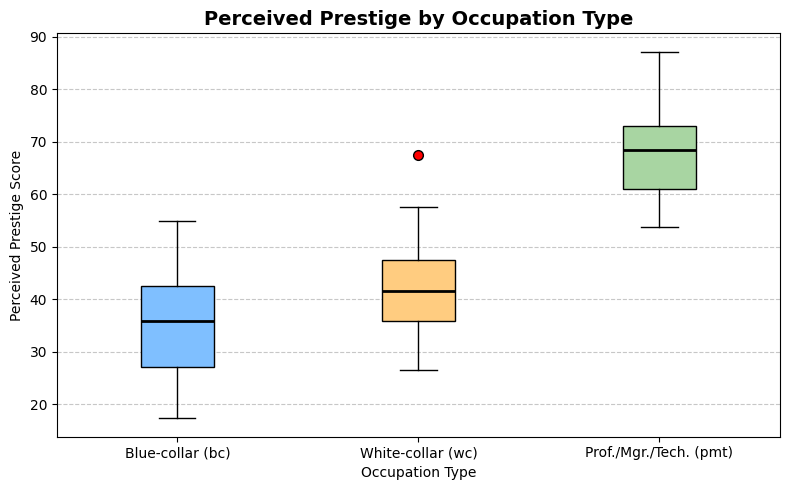

```python
import matplotlib.pyplot as plt

type_order = ["bc", "wc", "pmt"]
type_labels = ["Blue-collar (bc)", "White-collar (wc)", "Prof./Mgr./Tech. (pmt)"]
data_by_type = [
    df_imputed[df_imputed["type"] == t]["perceivedprestige"] for t in type_order
]

fig, ax = plt.subplots(figsize=(8, 5))

bp = ax.boxplot(
    data_by_type,
    tick_labels=type_labels,
    patch_artist=True,
    medianprops=dict(color="black", linewidth=2),
    flierprops=dict(marker="o", markerfacecolor="red", markersize=7, linestyle="none"),
)

colors = ["#7fbfff", "#ffcc80", "#a8d5a2"]
for patch, color in zip(bp["boxes"], colors):
    patch.set_facecolor(color)

ax.set_title("Perceived Prestige by Occupation Type", fontsize=14, fontweight="bold")
ax.set_ylabel("Perceived Prestige Score")
ax.set_xlabel("Occupation Type")
ax.yaxis.grid(True, linestyle="--", alpha=0.7)
ax.set_axisbelow(True)

plt.tight_layout()
plt.savefig("prestige_by_type.png", dpi=150)
plt.show()
```

## Q2c) Handling Categorical Variables (Dummy Coding)

```python
# Create dummy variables for 'type' with 'wc' (white collar) as the reference level
dummies = pd.get_dummies(df_imputed["type"], prefix="type", drop_first=False)
dummies = dummies.drop(columns="type_wc").astype(
    int
)  # drop wc — it is the reference level

df_model = pd.concat([df_imputed.drop(columns="type"), dummies], axis=1)

print("Dummy columns added (reference: wc):", dummies.columns.tolist())
df_model[["occupation", "type_bc", "type_pmt"]].head()
```

```
Dummy columns added (reference: wc): ['type_bc', 'type_pmt']
```

|  | occupation | type_bc | type_pmt |
| --- | --- | --- | --- |
| 0 | nursing.aides | 1 | 0 |
| 1 | service.station.attendant | 1 | 0 |
| 2 | firefighters | 1 | 0 |
| 3 | policemen | 1 | 0 |
| 4 | cooks | 1 | 0 |

## 2d) Building a model

```python
import numpy as np
import statsmodels.formula.api as smf

df_model["log_income"] = np.log(df_model["income"])

model1 = smf.ols(
    "perceivedprestige ~ education + log_income + type_bc + type_pmt", data=df_model
).fit()

print(model1.summary())
```

```
                            OLS Regression Results
==============================================================================
Dep. Variable:      perceivedprestige   R-squared:                       0.854
Model:                            OLS   Adj. R-squared:                  0.848
Method:                 Least Squares   F-statistic:                     136.1
Date:                Fri, 13 Mar 2026   Prob (F-statistic):           5.48e-38
Time:                        09:49:07   Log-Likelihood:                -322.44
No. Observations:                  98   AIC:                             654.9
Df Residuals:                      93   BIC:                             667.8
Df Model:                           4
Covariance Type:            nonrobust
==============================================================================
                 coef    std err          t      P>|t|      [0.025      0.975]
------------------------------------------------------------------------------
Intercept    -83.5073     14.115     -5.916      0.000    -111.537     -55.478
education      3.4130      0.605      5.644      0.000       2.212       4.614
log_income    10.4223      1.735      6.006      0.000       6.976      13.868
type_bc        1.8981      2.371      0.800      0.426      -2.811       6.607
type_pmt       7.5668      2.627      2.881      0.005       2.351      12.783
==============================================================================
Omnibus:                        0.018   Durbin-Watson:                   1.885
Prob(Omnibus):                  0.991   Jarque-Bera (JB):                0.030
Skew:                           0.006   Prob(JB):                        0.985
Kurtosis:                       2.915   Cond. No.                         299.
==============================================================================

Notes:
[1] Standard Errors assume that the covariance matrix of the errors is correctly specified.
```

### i. Hypothesis tests: H₀: βⱼ = 0

At the 5% significance level:

| Predictor | p-value | Reject H₀? |
| --- | --- | --- |
| `education` | < 0.001 | Yes |
| `log_income` | < 0.001 | Yes |
| `type_pmt` | 0.005 | Yes |
| `type_bc` | 0.426 | No |

`education`, `log_income`, and `type_pmt` are all statistically significant. `type_bc` is not — after controlling for education and income, blue-collar occupations do not differ significantly in prestige from the white-collar reference group.

### ii. Overall model fit

The model explains **85.4%** of the variance in perceived prestige (R² = 0.854, Adj. R² = 0.848). The F-statistic is 136.1 (p < 0.001), confirming the model is highly significant overall. This constitutes a **meaningful fit**: the four predictors together account for the large majority of variation in prestige, with residuals that are approximately normal (p = 0.985).

## 2e) Interpretation

### i. `type_bc` (Blue-collar vs. White-collar)

β = +1.90 (p = 0.426). Holding education and log-income constant, blue-collar occupations score 1.90 prestige points higher than white-collar on average. This is **not statistically significant**, so there is no meaningful prestige difference between the two groups.

### ii. `type_pmt` (Professional/Managerial/Technical vs. White-collar)

β = +7.57 (p = 0.005). Holding education and log-income constant, pmt occupations score **7.57 prestige points higher** than white-collar on average. This is **statistically significant**, indicating that pmt occupations carry a genuine prestige premium over white-collar jobs.

## 2f) Statistical Significance of `type_bc` and `type_pmt`

### `type_bc`

`type_bc` is **not statistically significant** (β = +1.90, t = 0.80, p = 0.426, 95% CI: [−2.81, 6.61]). The p-value of 0.426 far exceeds the 5% threshold, and the confidence interval includes zero, meaning the true coefficient could be zero or even negative. This shows that, after controlling for education and income, being blue-collar does not offer any discernible prestige difference relative to white-collar occupations.

### `type_pmt`

`type_pmt` is **statistically significant** (β = +7.57, t = 2.88, p = 0.005, 95% CI: [2.35, 12.78]). The p-value is well below 0.05 and the confidence interval lies entirely above zero. This reveals that professional/managerial/technical occupations command a meaningful prestige premium over white-collar occupations that cannot be explained by differences in education or income alone.

## 2g) Building Another Model

```python
model2 = smf.ols(
    "perceivedprestige ~ log_income + type_bc + type_pmt"
    " + log_income:type_bc + log_income:type_pmt",
    data=df_model,
).fit()

print(model2.summary())
```

```
                            OLS Regression Results
==============================================================================
Dep. Variable:      perceivedprestige   R-squared:                       0.817
Model:                            OLS   Adj. R-squared:                  0.808
Method:                 Least Squares   F-statistic:                     82.40
Date:                Fri, 13 Mar 2026   Prob (F-statistic):           1.91e-32
Time:                        09:49:07   Log-Likelihood:                -333.41
No. Observations:                  98   AIC:                             678.8
Df Residuals:                      92   BIC:                             694.3
Df Model:                           5
Covariance Type:            nonrobust
=======================================================================================
                          coef    std err          t      P>|t|      [0.025      0.975]
---------------------------------------------------------------------------------------
Intercept             -40.6506     34.811     -1.168      0.246    -109.788      28.487
log_income              9.8028      4.112      2.384      0.019       1.635      17.971
type_bc               -84.8583     42.120     -2.015      0.047    -168.512      -1.205
type_pmt               25.6852     44.959      0.571      0.569     -63.608     114.978
log_income:type_bc      9.1392      4.967      1.840      0.069      -0.726      19.005
log_income:type_pmt    -0.7856      5.147     -0.153      0.879     -11.007       9.436
==============================================================================
Omnibus:                        3.815   Durbin-Watson:                   1.855
Prob(Omnibus):                  0.148   Jarque-Bera (JB):                3.257
Skew:                           0.434   Prob(JB):                        0.196
Kurtosis:                       3.211   Cond. No.                         864.
==============================================================================

Notes:
[1] Standard Errors assume that the covariance matrix of the errors is correctly specified.
```

### i. Effect of log(income) on prestige for blue-collar occupations

For blue-collar occupations (`type_bc` = 1), the effect of `log_income` on perceived prestige is the sum of the main effect and the interaction term:

**9.80 + 9.14 = 18.94**

A one-unit increase in log(income) is associated with an estimated **18.94-point increase** in perceived prestige for blue-collar workers.

### ii. Perceived prestige equation for blue-collar occupations

Substituting `type_bc` = 1 and `type_pmt` = 0:

$$\hat{prestige} = (-40.65 - 84.86) + (9.80 + 9.14) \times \log(income)$$ $$= -125.51 + 18.94 \times \log(income)$$

### iii. Interpretation

The interaction term `log_income:type_bc` (β = +9.14, p = 0.069) suggests that income has a **stronger positive effect** on prestige for blue-collar workers than for white-collar workers, though this difference is only marginally significant. The interaction for `type_pmt` (β = −0.79, p = 0.879) is negligible and not significant, meaning the income–prestige relationship is essentially the same for pmt and white-collar occupations. Overall, model2 has a lower R² (0.817) than model1 (0.854), suggesting that adding the interaction terms without `education` does not improve fit.